# 응용프로그래밍 중간고사

coop711

2018-10-21

학번 ________________

이름 ________________

1. 다음 `VADeaths`를 그 아래의 깔끔한(tidy) `VADeaths_tbl` 로 바꾸는 과정을 흐트러 놓았다. 순서대로 정리하시오.

```r
VADeaths
```

```
##       Rural Male Rural Female Urban Male Urban Female
## 50-54       11.7          8.7       15.4          8.4
## 55-59       18.1         11.7       24.3         13.6
## 60-64       26.9         20.3       37.0         19.3
## 65-69       41.0         30.9       54.6         35.1
## 70-74       66.0         54.3       71.1         50.0
```

```r
VADeaths_tbl
```

```
## # A tibble: 20 x 4
##    Age   Place Gender Rates
##    <ord> <fct> <fct>  <dbl>
##  1 50-54 Rural Male    11.7
##  2 55-59 Rural Male    18.1
##  3 60-64 Rural Male    26.9
##  4 65-69 Rural Male    41
##  5 70-74 Rural Male    66
##  6 50-54 Rural Female   8.7
##  7 55-59 Rural Female  11.7
##  8 60-64 Rural Female  20.3
##  9 65-69 Rural Female  30.9
## 10 70-74 Rural Female  54.3
## 11 50-54 Urban Male    15.4
## 12 55-59 Urban Male    24.3
## 13 60-64 Urban Male    37
## 14 65-69 Urban Male    54.6
## 15 70-74 Urban Male    71.1
## 16 50-54 Urban Female   8.4
## 17 55-59 Urban Female  13.6
## 18 60-64 Urban Female  19.3
## 19 65-69 Urban Female  35.1
## 20 70-74 Urban Female  50
```

(가) `mutate(Age = row.names(VADeaths)) %>%`

(나) `as_tibble() %>%`

(라) `gather(key = Place_Gender, value = Rates, -Age) %>%`

(마) `separate(Place_Gender, c("Place", "Gender"), sep = " ") %>%`

(바) `mutate(Age = ordered(Age), Place = factor(Place), Gender = factor(Gender,`  
`levels = c("Male", "Female")))`

(사) `library(tidyverse)`

2. 위의 `VADeaths_tbl`을 이용하여 다음 막대그래프들을 그릴 때 [대괄호] 자리를 채우시오.

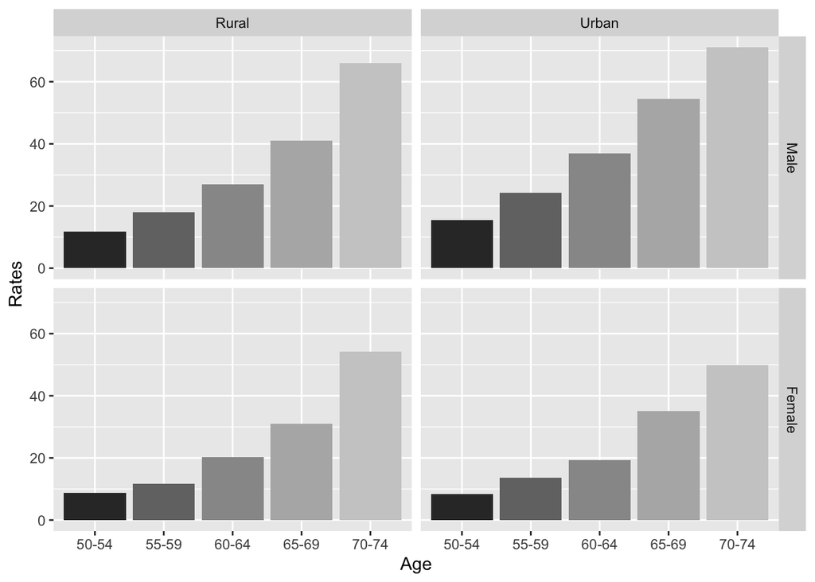

```
ggplot(data = VADeaths_tbl,
              mapping = aes(x = [대괄호],
                            y = [대괄호],
                            fill = [대괄호]) +
geom_bar(stat = "[대괄호]",
         position = position_[대괄호]()) +
scale_fill_grey([대괄호] = FALSE) +
facet_grid([대괄호] ~ [대괄호])
```

3. 아래 코드 묶음에서 한글이 꺠지는 현상과 관련있는 코드는 어느 부분인가?

```
class_roll <- read.table("../data/class_roll_masked.txt",
                         header = TRUE,
                         stringsAsFactors = FALSE,
                         encoding = "UTF-8")
str(class_roll)
```

가. `read.table`

나. `header = TRUE`

다. `stringsAsFactors = FALSE`

라. `encoding = "UTF-8"`

4. 아래 코드 묶음에서 괄호 안에 적절한 연산자는 무엇인가?

```
# set.seed(107)
N <- nrow(class_roll)
class_roll$group <- sample(1:N) (괄호) 2 + 1
class_roll$group <- factor(class_roll$group,
                           labels = c("Red", "Black"))
red_id <- which(class_roll$group == "Red")
black_id <- which(class_roll$group == "Black")
```

가. `%/%`

나. `%%`

다. `%*%`

라. `%o%`

5. 학번의 첫 네 자리를 읽어들여 16학번을 기준으로 나누고자 다음 코드를 실행하였다. 16학번인 사람은 어느 `label`을 부여받게 되는가?

```
ID_16 <- factor(ifelse(substr(class_roll$id, 1, 4) >= 2016,
                       "younger_16", "older_16"),
                levels = c("younger_16", "older_16"))
```

가. `younger_16`

나. `older_16`

다. `1`

라. `2`

6. email 서비스 업체가 랜덤하게 잘 나뉘었는지 살피기 위하여 다음 코드를 수행하고자 할 때 (괄호) 자리에 적합한 함수기호는?

```
email_list <- strsplit(class_roll$email, "@", fixed = TRUE)
mail_com <- sapply(email_list, `(괄호)`, 2)
kable(table("그룹" = class_roll$group,
            "e-mail" = mail_com))
```

가. `[`

나. `]`

다. `(`

라. `{`

7. 많이 나오는 성씨(김, 이, 박)들이 양 집단에 고르게 분포하는지 파악하기 위하여 다음 코드를 수행할 때 (괄호) 자리에 적합한 연산자를 고르시오.

```
f_name_f <- factor(ifelse(f_name (괄호)  c("김", "이", "박"),
                          f_name, "기타"),
                   levels = c("김", "이", "박", "기타"))
kable(table("Group" = class_roll$group,
            "Family Name" = f_name_f))
```

가. `%in%`

나. `%%`

다. `%*%`

라. `%o%`

8. 전화번호 끝 네 자리가 천 단위로 균일한 분포에 따르는지 파악하고자 다음 코드를 수행할 때 [대괄호] 자리에 적합한 R 함수는 무엇인가?

```
cell_numbers <- sapply(substr(class_roll$cell_no, 5, 8),
                       as.numeric)
cut_label <- paste(paste0(1:9, "000"), paste0(1:9, "999"), sep = "~")
kable(t(table([대괄호](cell_numbers,
                  labels = cut_label,
                  breaks = seq(1000, 10000, by = 1000)))))
hist(cell_numbers)
```

가. `cut`

나. `trim`

다. `cutree`

라. `stem`

9. 아래 코드묶음으로부터 `names(class_roll)[4]`의 결과는 어떻게 나오겠는가?

```
class_roll <- read.xlsx("../data/class_roll1801.xlsx",
                        sheetIndex = 1,
                        startRow = 2,
                        endRow = 15,
                        colIndex = c(3:7, 9),
                        colClasses = rep("character", 6),
                        encoding = "UTF-8",
                        stringsAsFactors = FALSE)
names(class_roll) <- c("dept", "id", "name", "year", "email", "cell_no")
names(class_roll)[4]
```

가. `## [1] "dept"`

나. `## [1] "id"`

다. `## [1] "name"`

라. `## [1] "year"`

10. 위의 코드 묶음에서 `kable(class_roll)`의 결과가 제대로 나오려면 어떤 코드가 먼저 성공적으로 실행되었어야 하는가?

가. `install.packages("knitr")`

나. `library(knitr)`

다. `update.packages("knitr")`

라. `remove.packages("knitr")`

11. 학번은 입학연도를 나타내는 첫 네자리와 개인 식별번호로 구성되어 있다. 여기서, 개인식별번호를 “9999”로 가리고자 할 때 아래 코드 묶음에서 (괄호) 자리에 적합한 R 함수는 무엇인가?

```
(괄호)(class_roll$id, start = 5, stop = 8) <- "9999"
```

가. `sub`

나. `substr`

다. `strsplit`

라. `substring`

12. 각 이름의 2번째 글자 이후를 모두 “ㅇㅇ”으로 대체하고자 할 때 아래 코드 묶음에서 (괄호) 자리에 적합한 R 함수는 무엇인가?

```
(괄호)(class_roll$name, first = 2) <- "ㅇㅇ"
```

가. `sub`

나. `substr`

다. `strsplit`

라. `substring`

13. 모바일 폰 번호의 끝 네 자리를 “xxxx” 로 대체하고자 할 때, 아래 코드 묶음에서 (괄호) 자리에 적합한 R 함수는 무엇인가? (정상적으로 번호가 나올 경우 열번째 글자부터 열세번째글자에 해당한다).

```
(괄호)(class_roll$cell_no, first = 10, last = 13) <- "xxxx"
kable(head(class_roll))
```

가. `sub`

나. `substr`

다. `strsplit`

라. `substring`

14. 전공 단위 이름은 “학과”, “과”, “학”, “전공” 등 매우 다양한 명칭이 있으므로 “ㅇㅇ학과” 로 대체하고자 할 때 괄호에 적합한 R 함수는 무엇인가?

```
class_roll$dept <- (   )("^.+$", "ㅇㅇ학과", class_roll$dept)
```

가. `sub`

나. `substr`

다. `strsplit`

라. `substring`

15. email 주소는 `@`를 사이에 두고 나뉘어진다. email 주소에서 서비스업체명은 그대로 두고 개인 식별이 가능한 이름 부분을 `user_name`으로 대체하고자 할 때 괄호에 적합한 R 함수는 무엇인가?

```
class_roll$email <- (괄호)("^.+@", "user_name@", class_roll$email)
```

가. `sub`

나. `substr`

다. `strsplit`

라. `substring`

16. 다음 코드에서 각 일련변호를 랜덤하게 늘어놓은 후 5로 나눈 나머지를 구하는 코드는 무엇인가?

```
set.seed(3)
N <- nrow(class_roll)
group <- 1 + sample(1:N) %% 5
class_roll$group <- factor(group, levels = 1:5, labels = paste("Team", 1:5))
```

가. `set.seed(3)`

나. `N <- nrow(class_roll)`

다. `sample(1:N) %% 5`

라. `group <- 1 + sample(1:N) %% 5`

17. 다음 코드묶음에서 학번 첫 네자리를 추출하는 코드는 무엇인가?

```
ID_14 <- factor(ifelse(substr(class_roll$id, 1, 4) >= 2014,
                       "younger.14", "older.14"),
                levels = c("younger.14", "older.14"),
                labels = c("14학번 이후", "13학번 이전"))
```

가. `class_roll$id`

나. `substr(class_roll$id, 1, 4)`

다. `ifelse(substr(class_roll$id, 1, 4) >= 2014, "younger.14", "older.14")`

라. `factor(ifelse(substr(class_roll$id, 1, 4) >= 2014, "younger.14", "older.14"))`

18. 다음 코드묶음에서 e-mail 주소의 사용자이름과 서비스 업체 도메인 명의 리스트에서 도메인명들만을 추출하는 코드는 무엇인가?

```
email_list <- strsplit(class_roll$email, "@", fixed = TRUE)
mail_com <- sapply(email_list, "[", 2)
```

가. `class_roll$email`

나. `strsplit(class_roll$email, "@", fixed = TRUE)`

다. `sapply(email_list, "[", 2)`

라. `mail_com <- sapply(email_list, "[", 2)`

19. 수강생별로 각 성격유형의 점수 합계를 계산하기 위해 아래의 명령어를 사용하였다. [대괄호] 자리에 들어 갈 함수를 옳게 늘어놓은 것은?

```
BFI_score <- data.frame([대괄호](abb_BFI, function(x) [대괄호](BFI_data[, [대괄호](names(BFI_data), 1, 1) == x], 1, [대괄호])))
```

가. `sapply, apply, substr, sum`

나. `apply, sapply, substr, sum`

다. `sapply, apply, sum, substr`

라. `apply, sapply, substr, sum`

20. 집합 연산에서 차집합을 구하는 `R`함수는 다음 중 어느 것인가?

가. `setdiff()`

나. `diff()`

다. `difftime()`

라. `is.na()`

21. 아래의 명령어에서 `join()`을 활용하여 데이터를 합했다. `default`로 설정되어 있는 `type =`?

    ```
    BFI_full_kr <- join(class_roll, BFI_level_kr_2, by = "ID")
    ```

가. `"left"`

나. `"right"`

다. `"inner"`

라. `"full"`